# SPAM/HAM Dashboard

[figure not shown]

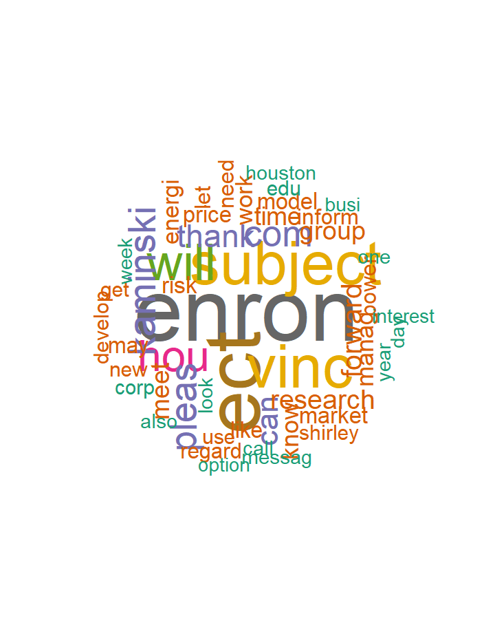

[figure not shown]

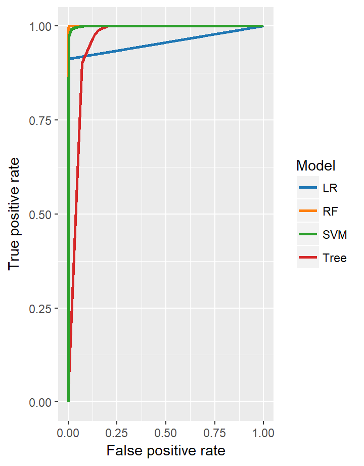

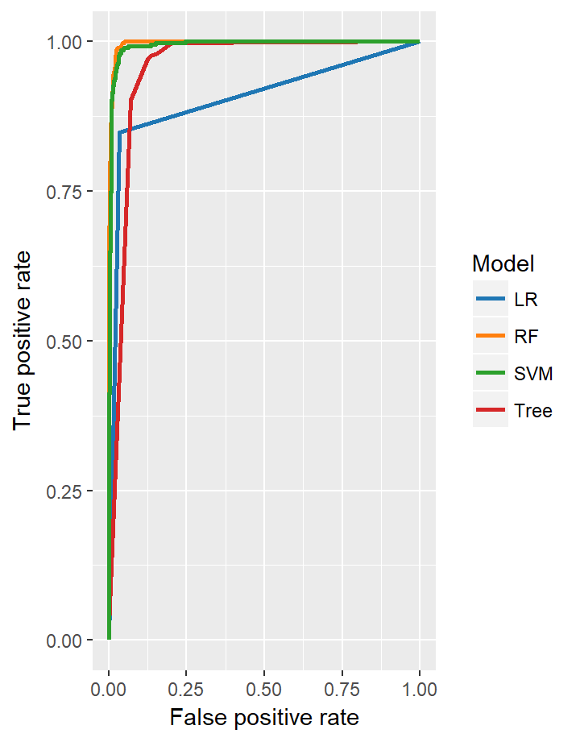

# Intro

This dashboard covers several possible classification techniques that might be use to predict Spam/Not Spam emails.

# Data

#### Separating spam from ham

Nearly every email user has at some point encountered a “spam” email, which is an unsolicited message often advertising a product, containing links to malware, or attempting to scam the recipient. Roughly 80-90% of more than 100 billion emails sent each day are spam emails, most being sent from botnets of malware-infected computers. The remainder of emails are called “ham” emails.

As a result of the huge number of spam emails being sent across the Internet each day, most email providers offer a spam filter that automatically flags likely spam messages and separates them from the ham. Though these filters use a number of techniques (e.g. looking up the sender in a so-called “Blackhole List” that contains IP addresses of likely spammers), most rely heavily on the analysis of the contents of an email via text analytics.

In this problem, we will build and evaluate a spam filter using a publicly available dataset first described in the 2006 conference paper “Spam Filtering with Naive Bayes – Which Naive Bayes?” by V. Metsis, I. Androutsopoulos, and G. Paliouras. The “ham” messages in this dataset come from the inbox of former Enron Managing Director for Research Vincent Kaminski, one of the inboxes in the Enron Corpus. One source of spam messages in this dataset is the SpamAssassin corpus, which contains hand-labeled spam messages contributed by Internet users. The remaining spam was collected by Project Honey Pot, a project that collects spam messages and identifies spammers by publishing email address that humans would know not to contact but that bots might target with spam. The full [dataset](https://prod-edxapp.edx-cdn.org/assets/courseware/v1/8ead76b237d8690efbe2b634d855f1dc/asset-v1:MITx+15.071x_3+1T2016+type@asset+block/emails.csv) we will use was constructed as roughly a 75/25 mix of the ham and spam messages.

The dataset contains just two fields:

- `text`: The text of the email.
- `spam`: A binary variable indicating if the email was spam.

The dataset and its description were proposed as a homework at the online MIT course [“The Analytics Edge”](https://www.edx.org/course/analytics-edge-mitx-15-071x-3) provided by [edX](https://www.edx.org/).

#### Data

```
'data.frame':   5728 obs. of  2 variables:
 $ text: chr  "Subject: naturally irresistible your corporate identity  lt is really hard to recollect a company : the  market"| __truncated__ "Subject: the stock trading gunslinger  fanny is merrill but muzo not colza attainder and penultimate like esmar"| __truncated__ "Subject: unbelievable new homes made easy  im wanting to show you this  homeowner  you have been pre - approved"| __truncated__ "Subject: 4 color printing special  request additional information now ! click here  click here for a printable "| __truncated__ ...
 $ spam: int  1 1 1 1 1 1 1 1 1 1 ...
```

# Word Clouds

### SPAM

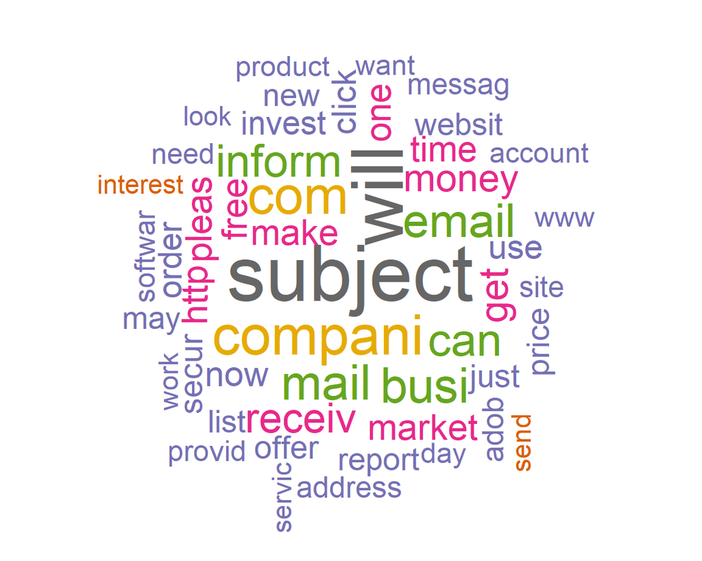

### HAM

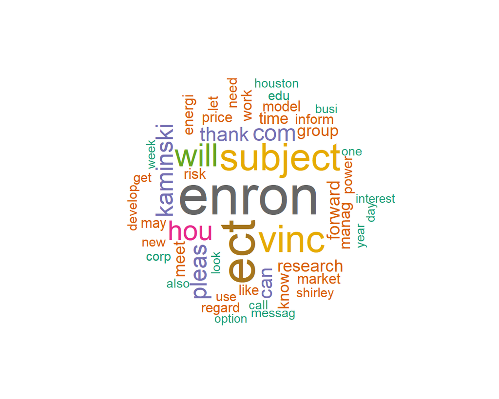

### Top20 Words SPAM

```
      Word Freq
1  subject 1577
2     will 1450
3  compani 1065
4      com  999
5     mail  917
6     busi  897
7    email  865
8      can  831
9   inform  818
10  receiv  727
11     get  694
12   money  662
13   pleas  619
14    free  606
15    make  603
16  market  600
17    http  600
18    time  593
19     one  592
20     now  575
```

### Top20 Words HAM

```
       Word  Freq
1     enron 13388
2       ect 11417
3   subject  8625
4      vinc  8531
5      will  6802
6       hou  5569
7  kaminski  4801
8     pleas  4494
9       com  4444
10    thank  3558
11      can  3426
12  forward  2952
13 research  2752
14     time  2552
15     meet  2544
16    group  2474
17     know  2345
18    manag  2334
19     work  2293
20    price  2191
```

# Bag of Words

### Model Description

#### Text Representation with Bag-of-Words Model

In order to use linear classifier on textual data set, we need to transform our data into numeric data. A popular and simple method is called the bag-of-words model of text. A bag-of-words is a representation of text that describes the occurrence of words within a document. It involves two things: a vocabulary of known words and a measure of the presence of known words. It is called a “bag” of words, because any information about the order or structure of words in the document is discarded. The model is only concerned with whether known words occur in the document.

```
[1] "What a waste of money and time!."
```

```
[1] "And the sound quality is great."
```

```
    Terms
Docs and money time waste what great quality sound the
   1   1     1    1     1    1     0       0     0   0
   2   1     0    0     0    0     1       1     1   1
```

As the vocabulary size increases, so does the vector representation of documents. There are simple text transforming techniques that can be used to reduce to the size of the vocabulary:

- Ignoring case
- Ignoring punctuation
- Ignoring stop words, like “a,” “of,” etc.
- Reducing words to their stem

# Logistic Regression

### Logistic Regression Model

#### Model

```
Warning: glm.fit: algorithm did not converge
```

```
Warning: glm.fit: fitted probabilities numerically 0 or 1 occurred
```

Both of these messages often indicate overfitting.

```
Call:
glm(formula = Spam ~ ., family = "binomial", data = Data)

Deviance Residuals:
   Min      1Q  Median      3Q     Max
 -8.49    0.00    0.00    0.00    8.49

Coefficients:
              Estimate Std. Error    z value Pr(>|z|)
(Intercept) -6.891e+13  2.591e+06  -26592687   <2e-16 ***
busi         9.341e+12  1.357e+06    6884830   <2e-16 ***
chang       -9.643e+13  2.195e+06  -43942654   <2e-16 ***
compani      7.363e+13  1.256e+06   58647017   <2e-16 ***
corpor       1.558e+13  2.901e+06    5370193   <2e-16 ***
day         -6.887e+13  1.663e+06  -41414099   <2e-16 ***
done         2.253e+13  4.813e+06    4679887   <2e-16 ***
effect       2.604e+14  4.136e+06   62963476   <2e-16 ***
effort      -4.446e+13  3.374e+06  -13177692   <2e-16 ***
even        -1.205e+13  3.253e+06   -3703342   <2e-16 ***
full         2.493e+14  3.653e+06   68245271   <2e-16 ***
good         1.143e+14  2.702e+06   42282398   <2e-16 ***
inform       7.204e+13  1.477e+06   48784323   <2e-16 ***
interest     2.415e+14  1.874e+06  128863064   <2e-16 ***
list         6.619e+12  1.755e+06    3770257   <2e-16 ***
look         2.557e+13  1.939e+06   13187839   <2e-16 ***
made         1.154e+14  3.814e+06   30266360   <2e-16 ***
make         2.932e+13  1.933e+06   15167879   <2e-16 ***
manag       -3.460e+13  1.361e+06  -25418564   <2e-16 ***
market       2.500e+13  1.042e+06   23984682   <2e-16 ***
much         3.329e+13  3.105e+06   10723030   <2e-16 ***
order        3.630e+13  1.606e+06   22599522   <2e-16 ***
origin       2.648e+14  2.655e+06   99748552   <2e-16 ***
product      5.925e+13  1.944e+06   30477840   <2e-16 ***
provid      -8.239e+13  2.226e+06  -37010309   <2e-16 ***
realli       1.571e+14  4.437e+06   35401016   <2e-16 ***
result       3.310e+13  3.158e+06   10480653   <2e-16 ***
see         -6.094e+13  2.241e+06  -27193155   <2e-16 ***
special      1.785e+14  3.604e+06   49537486   <2e-16 ***
subject     -1.516e+13  1.914e+06   -7922968   <2e-16 ***
system       2.883e+13  1.826e+06   15787302   <2e-16 ***
use         -7.552e+13  1.533e+06  -49261322   <2e-16 ***
websit       6.058e+13  2.267e+06   26719840   <2e-16 ***
will        -8.547e+13  7.554e+05 -113144364   <2e-16 ***
within       2.574e+14  3.428e+06   75101891   <2e-16 ***
without      1.754e+14  4.558e+06   38476766   <2e-16 ***
continu     -5.846e+13  3.656e+06  -15990176   <2e-16 ***
group        5.890e+13  1.244e+06   47331167   <2e-16 ***
like         2.155e+13  1.742e+06   12372593   <2e-16 ***
trade       -1.042e+14  1.369e+06  -76077501   <2e-16 ***
tri          6.976e+13  3.231e+06   21589181   <2e-16 ***
approv      -5.980e+13  2.440e+06  -24513103   <2e-16 ***
ask          3.004e+13  2.456e+06   12233293   <2e-16 ***
complet     -2.011e+14  2.998e+06  -67081246   <2e-16 ***
credit       3.475e+13  1.575e+06   22064864   <2e-16 ***
form         1.608e+14  2.826e+06   56892427   <2e-16 ***
hear         2.429e+14  4.100e+06   59237263   <2e-16 ***
home         3.127e+13  2.436e+06   12833167   <2e-16 ***
new         -7.099e+13  1.354e+06  -52431034   <2e-16 ***
offer        2.033e+14  1.986e+06  102383906   <2e-16 ***
opportun    -2.276e+13  2.408e+06   -9454010   <2e-16 ***
rate         2.486e+13  2.006e+06   12394263   <2e-16 ***
take        -2.692e+13  2.246e+06  -11987100   <2e-16 ***
time        -5.438e+13  1.336e+06  -40715448   <2e-16 ***
visit        1.074e+14  1.891e+06   56804751   <2e-16 ***
want        -6.197e+13  1.902e+06  -32572284   <2e-16 ***
way          4.304e+13  2.978e+06   14452254   <2e-16 ***
addit       -2.608e+13  2.970e+06   -8781374   <2e-16 ***
click        1.280e+14  2.505e+06   51084089   <2e-16 ***
com         -4.457e+13  5.533e+05  -80567536   <2e-16 ***
fax          7.083e+13  1.698e+06   41709228   <2e-16 ***
mail         1.136e+14  1.628e+06   69754134   <2e-16 ***
messag       5.997e+13  1.629e+06   36813541   <2e-16 ***
now          2.573e+14  2.280e+06  112839903   <2e-16 ***
phone       -2.930e+13  2.371e+06  -12354244   <2e-16 ***
request     -1.693e+14  1.610e+06 -105122538   <2e-16 ***
version     -9.148e+13  2.704e+06  -33830747   <2e-16 ***
best        -5.574e+13  2.448e+06  -22765730   <2e-16 ***
end         -7.954e+13  2.086e+06  -38133747   <2e-16 ***
get          6.564e+13  1.533e+06   42821700   <2e-16 ***
great        6.845e+13  2.800e+06   24445252   <2e-16 ***
money        2.516e+14  2.289e+06  109913043   <2e-16 ***
softwar      2.596e+14  2.165e+06  119896016   <2e-16 ***
custom      -7.777e+12  2.465e+06   -3155405   <2e-16 ***
hello        3.381e+14  3.199e+06  105710006   <2e-16 ***
one          1.471e+14  1.847e+06   79644758   <2e-16 ***
onlin        4.189e+14  2.586e+06  162020575   <2e-16 ***
pleas       -3.643e+13  1.390e+06  -26201421   <2e-16 ***
access      -1.326e+14  2.242e+06  -59149281   <2e-16 ***
account      2.440e+14  1.535e+06  158910828   <2e-16 ***
allow        3.933e+13  4.017e+06    9789727   <2e-16 ***
alreadi     -2.220e+13  4.438e+06   -5003001   <2e-16 ***
also         2.005e+14  2.144e+06   93487804   <2e-16 ***
applic      -1.029e+13  2.651e+06   -3880558   <2e-16 ***
area        -6.816e+13  3.297e+06  -20675562   <2e-16 ***
assist       9.627e+13  3.352e+06   28722339   <2e-16 ***
base         1.063e+14  2.608e+06   40736110   <2e-16 ***
believ       1.686e+14  4.461e+06   37790750   <2e-16 ***
buy          5.022e+13  3.786e+06   13266817   <2e-16 ***
can         -9.752e+12  1.284e+06   -7594879   <2e-16 ***
cost        -5.479e+13  2.036e+06  -26915038   <2e-16 ***
creat        3.611e+14  3.891e+06   92809123   <2e-16 ***
current     -1.378e+13  2.386e+06   -5777763   <2e-16 ***
design      -6.941e+13  3.246e+06  -21384841   <2e-16 ***
develop      5.065e+13  1.007e+06   50283383   <2e-16 ***
differ       8.368e+13  3.258e+06   25681070   <2e-16 ***
director     7.506e+13  2.969e+06   25280170   <2e-16 ***
discuss     -1.986e+14  2.115e+06  -93895709   <2e-16 ***
due          1.485e+14  4.096e+06   36266011   <2e-16 ***
email        6.695e+13  1.118e+06   59906502   <2e-16 ***
event       -5.106e+12  2.298e+06   -2221466   <2e-16 ***
expect      -1.484e+14  3.273e+06  -45345231   <2e-16 ***
file         2.049e+13  1.906e+06   10748859   <2e-16 ***
forward     -9.292e+13  1.548e+06  -60041111   <2e-16 ***
futur        1.373e+14  3.140e+06   43726755   <2e-16 ***
gas          9.254e+11  1.450e+06     638199   <2e-16 ***
give         5.638e+13  2.881e+06   19572271   <2e-16 ***
given       -8.015e+12  4.657e+06   -1720915   <2e-16 ***
high         1.157e+14  2.864e+06   40397893   <2e-16 ***
import      -6.603e+13  3.922e+06  -16835857   <2e-16 ***
includ      -3.021e+13  2.463e+06  -12267522   <2e-16 ***
increas      1.243e+13  2.744e+06    4530146   <2e-16 ***
industri    -2.062e+14  2.346e+06  -87873089   <2e-16 ***
invest       2.374e+14  2.303e+06  103055547   <2e-16 ***
involv       4.605e+13  4.335e+06   10621864   <2e-16 ***
just         3.831e+13  2.404e+06   15938277   <2e-16 ***
know        -6.411e+13  2.357e+06  -27202800   <2e-16 ***
locat       -5.945e+13  3.652e+06  -16278946   <2e-16 ***
mani         1.853e+14  3.261e+06   56817878   <2e-16 ***
may         -3.988e+13  1.321e+06  -30202143   <2e-16 ***
mean         4.292e+13  4.618e+06    9294082   <2e-16 ***
mention      1.271e+14  4.496e+06   28269630   <2e-16 ***
might        5.588e+13  3.350e+06   16680874   <2e-16 ***
month       -3.830e+13  1.939e+06  -19751864   <2e-16 ***
need         4.710e+13  1.660e+06   28368466   <2e-16 ***
note         2.994e+13  2.998e+06    9984254   <2e-16 ***
number      -5.136e+13  2.162e+06  -23757743   <2e-16 ***
offic       -1.570e+14  2.178e+06  -72075433   <2e-16 ***
oper        -1.810e+13  2.386e+06   -7587224   <2e-16 ***
person      -6.756e+13  2.845e+06  -23748352   <2e-16 ***
posit       -1.132e+14  1.968e+06  -57504782   <2e-16 ***
possibl     -1.068e+14  3.224e+06  -33118472   <2e-16 ***
present     -1.340e+13  1.407e+06   -9523540   <2e-16 ***
price       -1.246e+13  9.846e+05  -12653526   <2e-16 ***
problem      3.578e+12  3.107e+06    1151728   <2e-16 ***
process      3.873e+13  2.283e+06   16959960   <2e-16 ***
project      6.882e+13  1.481e+06   46460439   <2e-16 ***
read        -9.357e+13  4.182e+06  -22373639   <2e-16 ***
relat       -2.486e+14  3.161e+06  -78644353   <2e-16 ***
report      -5.929e+13  1.560e+06  -38011027   <2e-16 ***
requir       2.981e+13  2.940e+06   10137715   <2e-16 ***
research    -1.561e+14  1.162e+06 -134364408   <2e-16 ***
resourc     -2.047e+14  3.020e+06  -67757494   <2e-16 ***
return       1.161e+14  3.608e+06   32179430   <2e-16 ***
review      -8.473e+13  1.864e+06  -45466192   <2e-16 ***
risk        -3.912e+13  1.095e+06  -35743533   <2e-16 ***
secur        1.517e+13  1.994e+06    7609038   <2e-16 ***
servic      -2.142e+13  1.635e+06  -13098916   <2e-16 ***
set         -1.591e+14  3.102e+06  -51269881   <2e-16 ***
short        1.042e+14  3.286e+06   31720263   <2e-16 ***
specif      -3.886e+14  4.129e+06  -94125147   <2e-16 ***
state        2.262e+14  1.971e+06  114759757   <2e-16 ***
term         6.918e+13  2.996e+06   23091062   <2e-16 ***
thing        1.955e+14  3.702e+06   52803652   <2e-16 ***
today       -8.150e+12  2.770e+06   -2942303   <2e-16 ***
two         -1.775e+14  2.668e+06  -66522255   <2e-16 ***
understand  -3.184e+13  3.567e+06   -8924419   <2e-16 ***
unit        -1.225e+14  2.336e+06  -52438034   <2e-16 ***
well        -1.038e+14  2.508e+06  -41380916   <2e-16 ***
work        -1.385e+14  1.433e+06  -96637719   <2e-16 ***
hour         3.713e+13  2.888e+06   12855207   <2e-16 ***
lot          5.017e+13  4.964e+06   10105886   <2e-16 ***
real         1.901e+14  2.598e+06   73167287   <2e-16 ***
right        1.333e+14  3.214e+06   41489858   <2e-16 ***
start        1.268e+14  2.507e+06   50572514   <2e-16 ***
follow      -7.544e+13  2.099e+06  -35938373   <2e-16 ***
name        -7.973e+13  1.884e+06  -42314329   <2e-16 ***
sent        -1.346e+14  2.818e+06  -47759407   <2e-16 ***
last        -8.541e+13  2.566e+06  -33287174   <2e-16 ***
avail        4.901e+13  2.408e+06   20348404   <2e-16 ***
first        9.475e+13  2.434e+06   38934334   <2e-16 ***
http         2.006e+14  2.266e+06   88535192   <2e-16 ***
join        -3.919e+14  3.943e+06  -99386934   <2e-16 ***
line        -9.634e+12  3.560e+06   -2706296   <2e-16 ***
next.        1.157e+14  2.416e+06   47881264   <2e-16 ***
remov        2.855e+14  3.406e+06   83812512   <2e-16 ***
repli        2.215e+14  4.113e+06   53851441   <2e-16 ***
wish         6.067e+13  4.088e+06   14842886   <2e-16 ***
www         -1.006e+14  2.475e+06  -40654151   <2e-16 ***
year        -1.369e+14  1.429e+06  -95796608   <2e-16 ***
back        -1.813e+14  2.740e+06  -66183825   <2e-16 ***
internet    -5.317e+13  2.686e+06  -19794409   <2e-16 ***
member       3.373e+13  2.971e+06   11352578   <2e-16 ***
receiv       8.561e+11  1.899e+06     450775   <2e-16 ***
site         8.660e+13  1.935e+06   44748339   <2e-16 ***
anoth       -8.166e+13  3.955e+06  -20649071   <2e-16 ***
associ      -1.075e+13  1.812e+06   -5934280   <2e-16 ***
comment     -3.499e+14  2.815e+06 -124329401   <2e-16 ***
corp         1.071e+14  1.477e+06   72529938   <2e-16 ***
date        -1.987e+13  2.154e+06   -9223055   <2e-16 ***
find        -1.117e+14  2.901e+06  -38517961   <2e-16 ***
free         8.478e+13  1.921e+06   44142003   <2e-16 ***
issu        -2.387e+14  2.515e+06  -94917713   <2e-16 ***
long        -1.419e+14  3.904e+06  -36345796   <2e-16 ***
move        -1.401e+14  2.955e+06  -47399345   <2e-16 ***
particip    -6.578e+12  2.259e+06   -2911565   <2e-16 ***
recent      -8.924e+13  4.334e+06  -20588985   <2e-16 ***
respons     -1.754e+14  2.914e+06  -60188897   <2e-16 ***
say          1.072e+13  3.772e+06    2843451   <2e-16 ***
week        -5.793e+13  1.951e+06  -29694780   <2e-16 ***
dear        -6.284e+13  3.490e+06  -18006183   <2e-16 ***
regard      -7.466e+13  2.123e+06  -35173869   <2e-16 ***
thank       -3.069e+14  1.593e+06 -192682364   <2e-16 ***
```

```
address     -9.902e+12  2.034e+06   -4869172   <2e-16 ***
contact      3.463e+13  2.097e+06   16514680   <2e-16 ***
engin        1.627e+14  3.085e+06   52741183   <2e-16 ***
etc         -4.618e+13  3.680e+06  -12548517   <2e-16 ***
immedi       4.922e+14  4.840e+06  101712655   <2e-16 ***
net          1.593e+14  2.514e+06   63382307   <2e-16 ***
per          8.192e+13  2.173e+06   37690339   <2e-16 ***
place        1.793e+14  4.102e+06   43709101   <2e-16 ***
respond      2.389e+14  4.404e+06   54259111   <2e-16 ***
sincer      -1.348e+14  4.413e+06  -30558534   <2e-16 ***
type        -4.409e+13  3.501e+06  -12594178   <2e-16 ***
come         9.969e+13  2.864e+06   34806278   <2e-16 ***
confirm     -4.554e+13  2.588e+06  -17597688   <2e-16 ***
analysi     -3.458e+14  3.112e+06 -111133705   <2e-16 ***
bring       -2.518e+13  4.458e+06   -5648357   <2e-16 ***
call        -1.749e+13  1.599e+06  -10936132   <2e-16 ***
data        -1.424e+14  1.715e+06  -83033831   <2e-16 ***
detail       1.081e+14  3.236e+06   33414389   <2e-16 ***
happi       -3.977e+13  4.191e+06   -9488301   <2e-16 ***
idea        -3.083e+14  4.433e+06  -69557784   <2e-16 ***
info        -8.489e+12  3.096e+06   -2741918   <2e-16 ***
send        -2.035e+14  2.218e+06  -91754092   <2e-16 ***
success      7.036e+13  3.175e+06   22157907   <2e-16 ***
sure         9.064e+13  4.243e+06   21360922   <2e-16 ***
team        -1.132e+14  2.050e+06  -55188466   <2e-16 ***
web         -1.800e+13  2.937e+06   -6126136   <2e-16 ***
don          4.490e+13  3.254e+06   13798690   <2e-16 ***
copi        -2.289e+14  2.137e+06 -107094945   <2e-16 ***
help        -1.264e+14  2.070e+06  -61053161   <2e-16 ***
part        -2.429e+14  3.385e+06  -71753587   <2e-16 ***
life         9.592e+14  3.560e+06  269435613   <2e-16 ***
meet         1.419e+13  1.114e+06   12732086   <2e-16 ***
sever        2.936e+14  4.362e+06   67311027   <2e-16 ***
question    -3.216e+14  2.426e+06 -132553513   <2e-16 ***
write        2.356e+13  4.247e+06    5547458   <2e-16 ***
think       -1.177e+14  2.376e+06  -49540681   <2e-16 ***
point       -1.168e+14  3.102e+06  -37660796   <2e-16 ***
let         -7.000e+13  2.842e+06  -24633020   <2e-16 ***
link         1.055e+14  3.385e+06   31166990   <2e-16 ***
communic     5.866e+13  8.083e+05   72569082   <2e-16 ***
contract     2.726e+13  2.454e+06   11106334   <2e-16 ***
either      -1.260e+14  5.277e+06  -23885026   <2e-16 ***
final        2.879e+14  3.449e+06   83469554   <2e-16 ***
howev       -3.564e+14  3.549e+06 -100412970   <2e-16 ***
peopl       -6.820e+13  2.681e+06  -25437147   <2e-16 ***
power       -8.833e+13  1.137e+06  -77675701   <2e-16 ***
put         -2.236e+14  4.276e+06  -52291869   <2e-16 ***
run          4.613e+12  3.638e+06    1267851   <2e-16 ***
shall        8.840e+13  2.727e+06   32416684   <2e-16 ***
soon        -6.285e+13  4.000e+06  -15714990   <2e-16 ***
support      1.050e+13  2.351e+06    4468353   <2e-16 ***
attach      -1.609e+14  2.181e+06  -73774944   <2e-16 ***
abl          1.093e+14  3.387e+06   32268741   <2e-16 ***
program     -4.861e+13  1.385e+06  -35102148   <2e-16 ***
sorri        1.859e+14  4.192e+06   44353502   <2e-16 ***
valu         6.290e+13  1.971e+06   31907214   <2e-16 ***
check       -3.749e+13  3.266e+06  -11479592   <2e-16 ***
feel        -2.302e+13  3.833e+06   -6005668   <2e-16 ***
better       1.744e+14  4.253e+06   41016247   <2e-16 ***
plan        -1.929e+14  2.031e+06  -94957288   <2e-16 ***
experi      -2.084e+13  4.145e+06   -5027993   <2e-16 ***
hope        -2.424e+14  2.976e+06  -81433257   <2e-16 ***
begin       -2.146e+14  5.090e+06  -42162477   <2e-16 ***
case        -9.493e+13  2.818e+06  -33692488   <2e-16 ***
depart      -3.100e+14  3.050e+06 -101639169   <2e-16 ***
financi     -4.688e+13  2.190e+06  -21401929   <2e-16 ***
houston     -1.443e+14  1.240e+06 -116390284   <2e-16 ***
intern       4.580e+13  2.648e+06   17297752   <2e-16 ***
john         9.164e+13  1.653e+06   55439418   <2e-16 ***
juli         1.866e+11  1.996e+06      93517   <2e-16 ***
mark        -2.299e+14  1.955e+06 -117594983   <2e-16 ***
open         1.358e+14  3.805e+06   35681030   <2e-16 ***
public      -1.403e+14  3.333e+06  -42087173   <2e-16 ***
sinc        -9.603e+13  3.681e+06  -26090402   <2e-16 ***
still       -1.738e+14  3.722e+06  -46704656   <2e-16 ***
thought     -2.121e+13  4.551e+06   -4661168   <2e-16 ***
univers      2.432e+13  2.355e+06   10330318   <2e-16 ***
appreci     -1.599e+14  3.864e+06  -41373515   <2e-16 ***
keep        -9.481e+13  3.840e+06  -24689681   <2e-16 ***
cours        1.495e+14  1.799e+06   83099215   <2e-16 ***
direct      -1.468e+14  3.106e+06  -47262281   <2e-16 ***
togeth      -1.534e+14  4.389e+06  -34942186   <2e-16 ***
energi      -4.301e+13  1.034e+06  -41579179   <2e-16 ***
london      -4.732e+13  1.892e+06  -25016654   <2e-16 ***
updat       -1.035e+14  2.587e+06  -40034041   <2e-16 ***
suggest     -2.312e+14  3.183e+06  -72655068   <2e-16 ***
option      -6.315e+13  1.292e+06  -48896275   <2e-16 ***
monday      -2.785e+14  3.026e+06  -92038568   <2e-16 ***
kevin       -2.026e+14  2.070e+06  -97912098   <2e-16 ***
book         6.950e+13  2.052e+06   33874742   <2e-16 ***
deal        -2.237e+13  2.739e+06   -8165285   <2e-16 ***
invit        2.148e+13  2.555e+06    8406271   <2e-16 ***
tuesday     -1.377e+14  3.273e+06  -42064910   <2e-16 ***
interview   -1.493e+14  1.428e+06 -104600092   <2e-16 ***
schedul     -3.125e+13  2.088e+06  -14969567   <2e-16 ***
school      -1.062e+14  2.452e+06  -43308481   <2e-16 ***
model       -1.344e+14  1.065e+06 -126218314   <2e-16 ***
financ      -7.109e+13  2.037e+06  -34907450   <2e-16 ***
morn        -1.871e+14  3.562e+06  -52519266   <2e-16 ***
attend      -3.817e+13  3.162e+06  -12071408   <2e-16 ***
robert      -4.267e+14  2.957e+06 -144309261   <2e-16 ***
student     -1.114e+14  2.016e+06  -55242688   <2e-16 ***
april        5.722e+13  2.419e+06   23649846   <2e-16 ***
talk         8.203e+12  2.457e+06    3338888   <2e-16 ***
arrang       1.760e+14  3.832e+06   45928694   <2e-16 ***
deriv       -4.028e+12  2.334e+06   -1725727   <2e-16 ***
thursday    -2.095e+14  3.021e+06  -69348848   <2e-16 ***
resum       -3.347e+13  1.826e+06  -18333014   <2e-16 ***
doc         -1.469e+14  2.345e+06  -62669160   <2e-16 ***
confer      -8.554e+13  1.350e+06  -63343836   <2e-16 ***
wednesday   -6.004e+13  3.515e+06  -17082963   <2e-16 ***
edu         -2.027e+13  8.214e+05  -24679990   <2e-16 ***
friday      -1.088e+13  2.417e+06   -4500925   <2e-16 ***
ect          1.227e+13  4.631e+05   26493707   <2e-16 ***
hou          1.575e+13  8.108e+05   19429526   <2e-16 ***
vinc        -2.829e+14  1.309e+06 -216147189   <2e-16 ***
shirley     -4.325e+14  3.157e+06 -136987582   <2e-16 ***
enron       -5.141e+13  2.971e+05 -173027256   <2e-16 ***
kaminski     4.903e+13  1.844e+06   26590230   <2e-16 ***
crenshaw     5.136e+14  4.196e+06  122413339   <2e-16 ***
vkamin      -1.035e+15  5.634e+06 -183700911   <2e-16 ***
gibner       3.420e+14  5.709e+06   59914997   <2e-16 ***
stinson     -6.916e+14  3.601e+06 -192042206   <2e-16 ***
---
Signif. codes:  0 '***' 0.001 '**' 0.01 '*' 0.05 '.' 0.1 ' ' 1
```

```
(Dispersion parameter for binomial family taken to be 1)

    Null deviance: 4409.5  on 4009  degrees of freedom
Residual deviance: 6704.1  on 3684  degrees of freedom
AIC: 7356.1

Number of Fisher Scoring iterations: 25
```

### Train

#### Performance on Training Dataset

```
[1] "Error Rate:"
[1] 0.02319202
[1] "Area Under Curve (AUC): "
[1] 0.9546842
```

### Test

#### Performance on Test Dataset

```
[1] "Error Rate:"
[1] 0.06169965
[1] "Area Under Curve (AUC): "
[1] 0.9075707
```

# Tree

#### Tree Structure

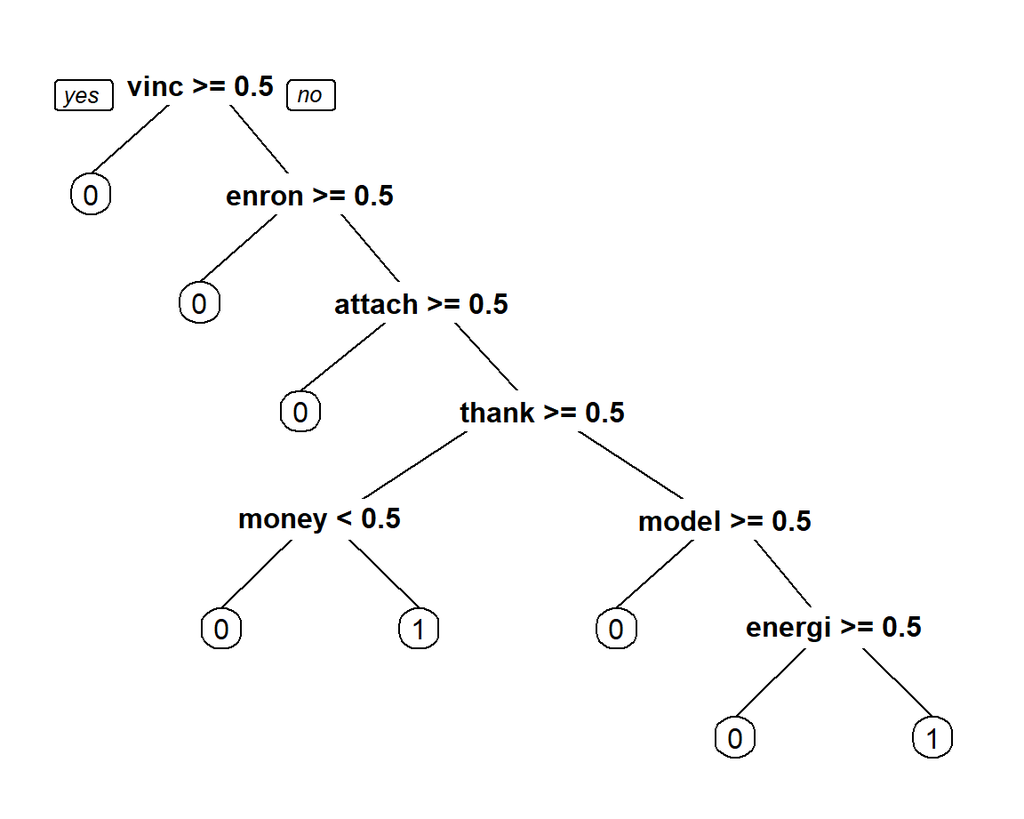

#### Tree Model

Cost-complexity pruning parameter `cp` is defined using 10-fold cross-validation.

```
n= 4010

node), split, n, loss, yval, (yprob)
      * denotes terminal node

  1) root 4010 958 0 (0.76109726 0.23890274)
    2) vinc>=0.5 1934   0 0 (1.00000000 0.00000000) *
    3) vinc< 0.5 2076 958 0 (0.53853565 0.46146435)
      6) enron>=0.5 502   0 0 (1.00000000 0.00000000) *
      7) enron< 0.5 1574 616 1 (0.39135959 0.60864041)
       14) attach>=0.5 149  10 0 (0.93288591 0.06711409) *
       15) attach< 0.5 1425 477 1 (0.33473684 0.66526316)
         30) thank>=0.5 266  93 0 (0.65037594 0.34962406)
           60) money< 0.5 231  62 0 (0.73160173 0.26839827) *
           61) money>=0.5 35   4 1 (0.11428571 0.88571429) *
         31) thank< 0.5 1159 304 1 (0.26229508 0.73770492)
           62) model>=0.5 67  10 0 (0.85074627 0.14925373) *
           63) model< 0.5 1092 247 1 (0.22619048 0.77380952)
            126) energi>=0.5 52  12 0 (0.76923077 0.23076923) *
            127) energi< 0.5 1040 207 1 (0.19903846 0.80096154) *
```

### Train

#### Performance on Training Dataset

```
[1] "Error Rate: "
[1] 0.07605985
[1] "Area Under Curve (AUC): "
[1] 0.958041
```

### Test

#### Performance on Test Dataset

```
[1] "Error Rate: "
[1] 0.07683353
[1] "Area Under Curve (AUC): "
[1] 0.956643
```

# Random Forest

#### Random Forest Model

```
Call:
 randomForest(formula = Spam ~ ., data = train, ntree = 100, importance = TRUE)
               Type of random forest: classification
                     Number of trees: 100
No. of variables tried at each split: 18

        OOB estimate of  error rate: 2.47%
Confusion matrix:
     0   1 class.error
0 3008  44  0.01441678
1   55 903  0.05741127
```

### Train

#### Performance on Training Dataset

```
[1] "Error Rate: "
[1] 0.001745636
[1] "Area Under Curve (AUC): "
[1] 0.9999938
```

### Test

#### Performance on Test Dataset

```
[1] "Error Rate: "
[1] 0.02444703
[1] "Area Under Curve (AUC): "
[1] 0.9967787
```

# Support Vector Machines

#### Support Vector Machines

```
Call:
svm(formula = Spam ~ ., data = train, kernel = "radial", cost = 10,
    gamma = 0.001, scale = FALSE)


Parameters:
   SVM-Type:  C-classification
 SVM-Kernel:  radial
       cost:  10
      gamma:  0.001

Number of Support Vectors:  746

 ( 358 388 )


Number of Classes:  2

Levels:
 0 1
```

### Train

#### Performance on Training Dataset

```
[1] "Error Rate: "
[1] 0.01396509
[1] "Area Under Curve (AUC): "
[1] 0.9990468
```

### Test

#### Performance on Test Dataset

```
[1] "Error Rate: "
[1] 0.03084983
[1] "Area Under Curve (AUC): "
[1] 0.9937924
```

# Perfromances

### *ROC* curves for the training set

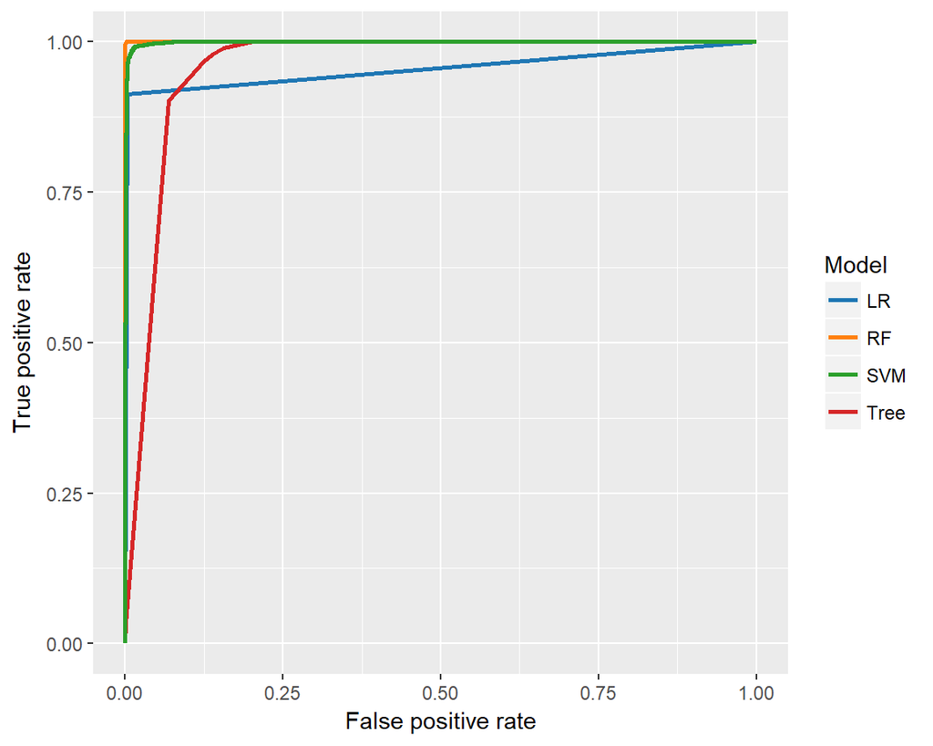

### *ROC* curves for the test set

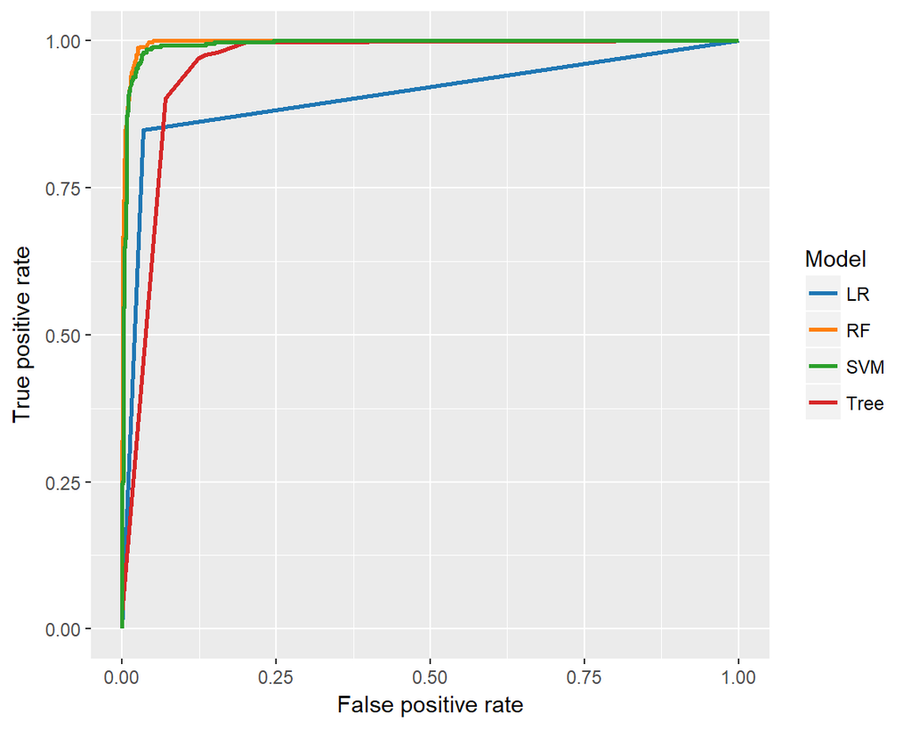